# National Commission on Muslim Filipinos

Budget evolution and agency-level utilization, FY 2018–2026

July 2026

← All agencies

# Overview

This document profiles the budget of the **National Commission on Muslim Filipinos (NCMF)** — the agency, formerly the Office on Muslim Affairs, mandated to promote the well-being of Muslim Filipinos and preserve their cultural, religious, and historical heritage — across nine fiscal years, FY 2018 to FY 2026. NCMF carries a particular data constraint: usable program-level execution records were not available, so this review pairs the **proposed-to-enacted budget at the program level** with **budget utilization measured at the agency aggregate**.

Because the program-by-program execution chain cannot be traced, the emphasis is on what NCMF’s budget is *composed of*, how Congress adjusts it, and — at the whole-agency level — how much of what is released actually gets obligated and paid out.

Three features define NCMF’s budget. First, it has **grown fast** — more than doubling since 2018. Second, it is **unusually concentrated**: a single line, the preservation of Muslim cultural centers and heritage, has been roughly **half the entire agency** every year. Third, NCMF has been **institutionally stable** — one move (from the Other Executive Offices to the DILG, around 2019) and **no change to its five-program structure** — so its trend lines read cleanly from 2018 to 2026.

Growth, though, is only half the picture. Set against the community NCMF serves — roughly **7.0 million Muslim Filipinos** by the 2020 census, and by NCMF’s own estimate considerably more — the 2026 budget works out to about **₱188 per person per year**, or roughly fifty centavos a day. The questions this review raises are therefore less about whether the agency spends what it receives (it largely does) than about **whether what it receives is adequate to the mandate, and whether the spending reaches the communities it is meant for**.

# 1 Executive summary

**NCMF’s enacted budget has more than doubled.** From ₱535M (2018 GAA) to ₱1,314M (2026) — about **+145%**, roughly 12% a year, with a steep ramp in 2025–2026.

**But the scale remains modest against the population it serves.** Spread across the roughly **7.0 million Muslim Filipinos** counted in the 2020 census, the 2026 budget is about **₱188 per person per year** — about fifty centavos a day — and closer to **₱110** if the community is as large as NCMF itself estimates.

**One organizational move, a stable structure.** NCMF (the former Office on Muslim Affairs) shifted from the **Other Executive Offices to the DILG around 2019** and has stayed there — *without* re-cutting its five-program structure, so program lines are comparable across all years.

**Half the budget is a single line.** Preservation of **Muslim cultural centers, heritage, holidays and festivities** has been **46–60% of the agency every year**, reaching ₱603M in 2026. With Hajj operations (₱104M) and Madrasah/Shari’ah education (₱142M), cultural, religious and educational services are the core of the budget — the functions the agency exists to deliver.

**Congress reliably tops up NCMF.** Enacted budgets matched or beat the proposal in eight of nine years; the **+₱148M (+13%) add for FY 2026** is the largest in the period.

**A delivery-oriented tilt.** Operating programs are about **75% of the 2026 budget**, and the personnel share of spending fell from **84% (2018) to 56% (2026)** as MOOE expanded.

**Execution is strong.** Agency-level obligation rates run **86–99%**, and NCMF disburses nearly everything it obligates — except **2019 (68% cash utilization)**, the OEO→DILG transition year.

> NCMF is a small, fast-growing agency with a stable structure that spends what it is given. The open questions are about **adequacy and reach**: whether an envelope of roughly fifty centavos per Muslim Filipino per day matches the mandate, and whether communities can see the spending arriving.

# 2 A note on the data

**Period.** FY 2018 through FY 2026 for the proposed (NEP) and enacted (GAA) budget, at the P/A/P level. Agency-level execution (Allotments, Obligations, Disbursements) covers FY 2011–2025.

**No program-level execution.** Usable **FAR No. 1** (SAAODB) records were not available for NCMF, so there is **no P/A/P-level absorption analysis**. Utilization is shown only at the **agency aggregate**.

**Two bases, not directly comparable.** The NEP/GAA figures are **current-year new appropriations only**. The execution figures are DBM’s **published agency aggregates, which combine all available funds** — new, automatic, and continuing appropriations. The two series should not be read one-to-one.

**One reorganization, a stable program structure.** NCMF’s mother agency changed once (**OEOs → DILG, ~2019**); its **P/A/P structure stayed stable** throughout, so program lines are comparable across all years.

**Population figures.** Per-person comparisons use the **2020 Census of Population and Housing**, which recorded **6,981,710 Filipinos (6.4%) reporting Islam** as their religious affiliation. NCMF has estimated the share at **10–11%**, citing under-registration and incomplete coverage of Muslim communities in official surveys. Per-person amounts here therefore use the census count and should be read as an **upper bound** — if the community is larger, the budget per person is smaller.

**Expense classes.** Personnel Services (PS), Maintenance & Other Operating Expenses (MOOE), Capital Outlays (CO). NCMF carries no Financial Expenses. **Units are PHP millions** throughout.

# 3 One move to DILG — a stable structure

NCMF changed mother agency once and otherwise kept its programs intact — so its trend lines run cleanly across all nine years.

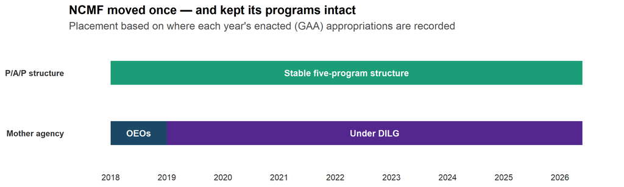

```r
tl <- tibble::tribble(
  ~track,            ~label,                          ~start, ~end,   ~fill,
  "Mother agency",   "OEOs",                           2018,   2019,   "#1B4965",
  "Mother agency",   "Under DILG",                     2019,   2026.4, "#54278F",
  "P/A/P structure", "Stable five-program structure",  2018,   2026.4, "#1B9E77")
ggplot(tl, aes(y = track)) +
  geom_segment(aes(x = start, xend = end, yend = track, color = fill), linewidth = 13, lineend = "butt") +
  scale_color_identity() +
  geom_text(aes(x = (start + end) / 2, label = label), color = "white", fontface = "bold", size = 3.6) +
  scale_x_continuous(breaks = 2018:2026, limits = c(2017.7, 2026.6)) +
  labs(title = "NCMF moved once — and kept its programs intact",
       subtitle = "Placement based on where each year's enacted (GAA) appropriations are recorded", x = NULL, y = NULL) +
  theme_ncmf() + theme(panel.grid.major.y = element_blank(),
        axis.text.y = element_text(face = "bold", color = "grey20"))
```

The same program lines run cleanly from 2018 to 2026, so the trends that follow can be read at face value.

# 4 The aggregate budget

## 4.1 A budget that more than doubled

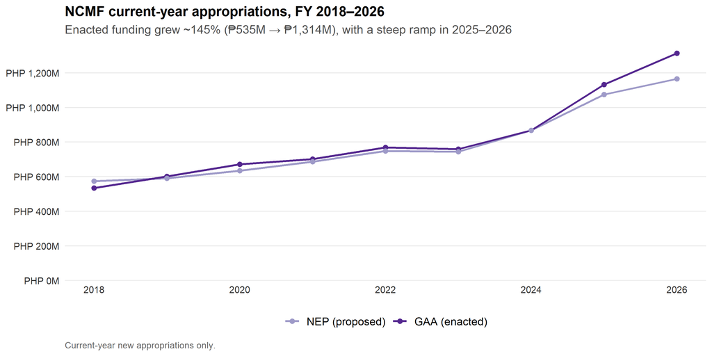

```r
evo <- totals %>% filter(metric %in% c("NEP","GAA")) %>%
  mutate(metric = factor(metric, levels = c("NEP","GAA"), labels = c("NEP (proposed)","GAA (enacted)")))
ggplot(evo, aes(year, total, color = metric, group = metric)) +
  geom_line(linewidth = 1.0) + geom_point(size = 2) +
  scale_color_manual(values = exec_pal) +
  scale_y_continuous(labels = php_m_axis, breaks = pretty_breaks(6), limits = c(0, NA), expand = expansion(mult = c(0, .05))) +
  scale_x_continuous(breaks = seq(2018, 2026, 2)) +
  labs(title = "NCMF current-year appropriations, FY 2018–2026",
       subtitle = "Enacted funding grew ~145% (₱535M → ₱1,314M), with a steep ramp in 2025–2026",
       x = NULL, y = NULL, caption = "Current-year new appropriations only.") +
  theme_ncmf() + guides(color = guide_legend(nrow = 1))
```

The budget grew at roughly 12% a year, accelerating recently — up ₱265M in FY 2025 and a further ₱181M in FY 2026. The proposed (NEP) and enacted (GAA) lines rarely diverge much: NCMF’s appropriations are largely Executive-led, with Congress fine-tuning at the margin.

```r
totals %>% filter(metric %in% c("NEP","GAA")) %>% mutate(value = total/1e6) %>%
  select(year, metric, value) %>% pivot_wider(names_from = year, values_from = value) %>%
  mutate(metric = factor(metric, levels = c("NEP","GAA"))) %>% arrange(metric) %>% rename(`PHP M` = metric) %>%
  kbl_clean(font = 13, digits = 0, format.args = list(big.mark = ","), na = "")
```

| PHP M | 2018 | 2019 | 2020 | 2021 | 2022 | 2023 | 2024 | 2025 | 2026 |
| --- | --- | --- | --- | --- | --- | --- | --- | --- | --- |
| NEP | 574 | 591 | 635 | 686 | 749 | 745 | 868 | 1,075 | 1,166 |
| GAA | 535 | 601 | 672 | 701 | 769 | 760 | 868 | 1,133 | 1,314 |

## 4.2 The budget per Muslim Filipino

Growth reads differently once the budget is set against the population NCMF exists to serve.

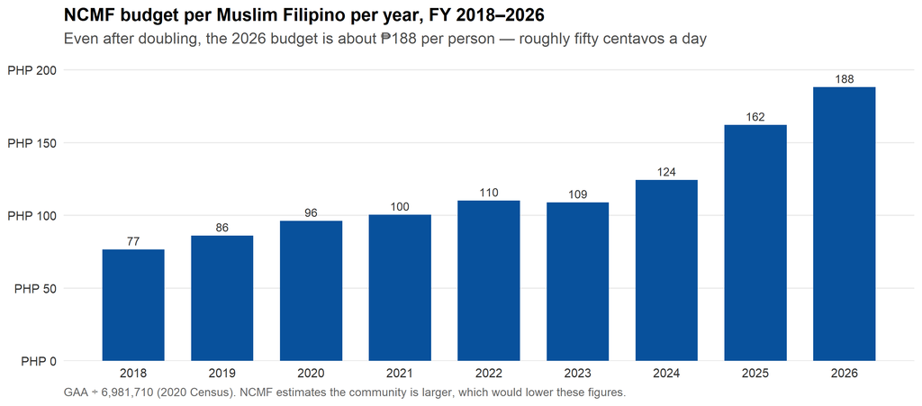

```r
CENSUS_MUSLIM <- 6981710   # 2020 Census of Population and Housing (6.4% reporting Islam)
pc <- totals %>% filter(metric == "GAA", !is.na(total)) %>%
  transmute(year, per_person = total / CENSUS_MUSLIM)
ggplot(pc, aes(year, per_person)) +
  geom_col(fill = bar_fill, width = 0.7) +
  geom_text(aes(label = sprintf("%.0f", per_person)), vjust = -0.5, size = 3.2, color = "grey20") +
  scale_x_continuous(breaks = 2018:2026) +
  scale_y_continuous(labels = function(v) paste0(peso, v), expand = expansion(mult = c(0, 0.12))) +
  labs(title = "NCMF budget per Muslim Filipino per year, FY 2018–2026",
       subtitle = "Even after doubling, the 2026 budget is about ₱188 per person — roughly fifty centavos a day",
       x = NULL, y = NULL,
       caption = "GAA ÷ 6,981,710 (2020 Census). NCMF estimates the community is larger, which would lower these figures.") +
  theme_ncmf()
```

On the census count, NCMF’s budget has risen from about **₱77 per Muslim Filipino in 2018 to ₱188 in 2026**. That is real growth — it has more than doubled — but the level remains small: roughly **fifty centavos per person per day** to cover cultural and heritage services, Hajj administration, Madrasah and Shari’ah education, livelihood programs, and the agency’s own operations.

The census figure is also the *generous* reading. NCMF has estimated that Muslim Filipinos are **10–11% of the population** rather than the 6.4% recorded in 2020, pointing to under-registration and incomplete survey coverage. On that basis the same budget would work out to roughly **₱110–120 per person per year**. Whichever figure is used, the per-person envelope is the context for everything that follows: NCMF spends what it is given reliably, so the binding question is how far that amount can stretch.

## 4.3 Where Congress adjusts the budget

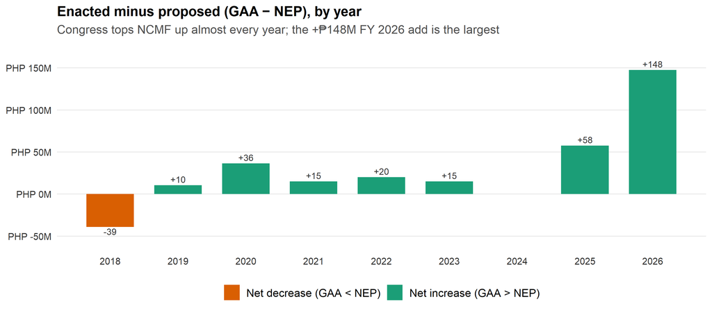

```r
gap <- totals %>% filter(metric %in% c("NEP","GAA")) %>% pivot_wider(names_from = metric, values_from = total) %>%
  mutate(change = GAA - NEP, direction = ifelse(change >= 0, "Net increase (GAA > NEP)", "Net decrease (GAA < NEP)"))
ggplot(gap, aes(year, change/1e6, fill = direction)) +
  geom_col(width = 0.7) +
  geom_text(aes(label = ifelse(abs(change) < 1e6, "", sprintf("%+.0f", change/1e6)),
                vjust = ifelse(change >= 0, -0.4, 1.2)), size = 3.2, color = "grey20") +
  scale_fill_manual(values = c("Net increase (GAA > NEP)" = "#1B9E77", "Net decrease (GAA < NEP)" = "#D95F02")) +
  scale_x_continuous(breaks = 2018:2026) +
  scale_y_continuous(labels = function(v) paste0(peso, v, "M"), expand = expansion(mult = c(0.16, 0.18))) +
  labs(title = "Enacted minus proposed (GAA − NEP), by year",
       subtitle = "Congress tops NCMF up almost every year; the +₱148M FY 2026 add is the largest", x = NULL, y = NULL) +
  theme_ncmf() + guides(fill = guide_legend(nrow = 1))
```

Congress **reliably augments** NCMF: the enacted budget met or exceeded the proposal in eight of nine years, the only cut being FY 2018 (−₱39M). The **+₱148M (+13%) plus-up for FY 2026** is the largest single adjustment in the period.

# 5 Where the money goes

## 5.1 Composition by PREXC program

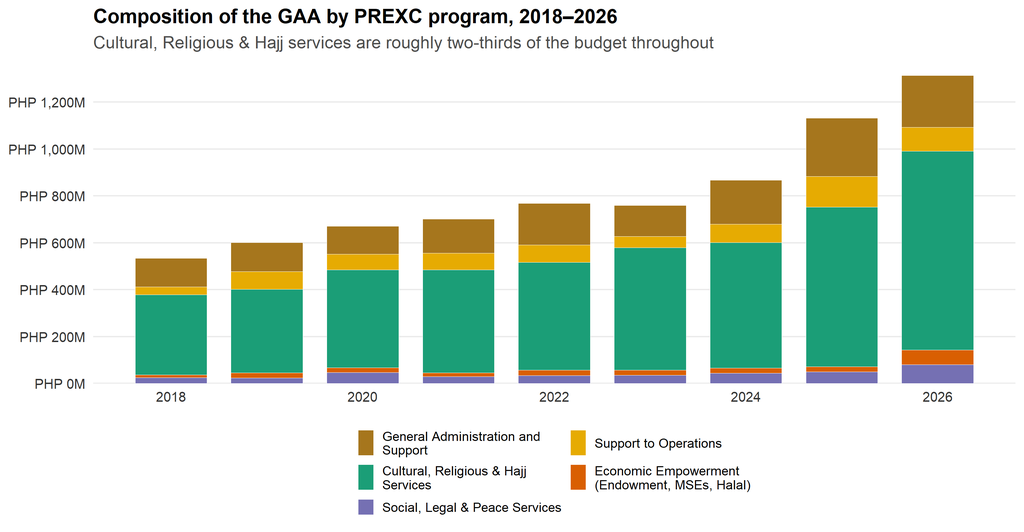

```r
comp <- df_long %>% filter(metric == "GAA", year <= 2026, !is.na(amount), !is.na(category)) %>%
  group_by(year, category) %>% summarise(amount = sum(amount, na.rm = TRUE), .groups = "drop") %>%
  mutate(category = factor(category, levels = names(cat_pal)))
ggplot(comp, aes(year, amount, fill = category)) +
  geom_col(width = 0.75, color = "white", linewidth = 0.2) +
  scale_fill_manual(values = cat_pal, labels = function(x) str_wrap(x, 30)) +
  scale_y_continuous(labels = php_m_axis, breaks = pretty_breaks(6), limits = c(0, NA), expand = expansion(mult = c(0, .05))) +
  scale_x_continuous(breaks = seq(2018, 2026, 2)) +
  labs(title = "Composition of the GAA by PREXC program, 2018–2026",
       subtitle = "Cultural, Religious & Hajj services are roughly two-thirds of the budget throughout", x = NULL, y = NULL) +
  theme_ncmf() + guides(fill = guide_legend(nrow = 3, byrow = TRUE)) +
  theme(legend.text = element_text(size = 9), legend.key.size = unit(0.4, "cm"))
```

## 5.2 Composition by expense class

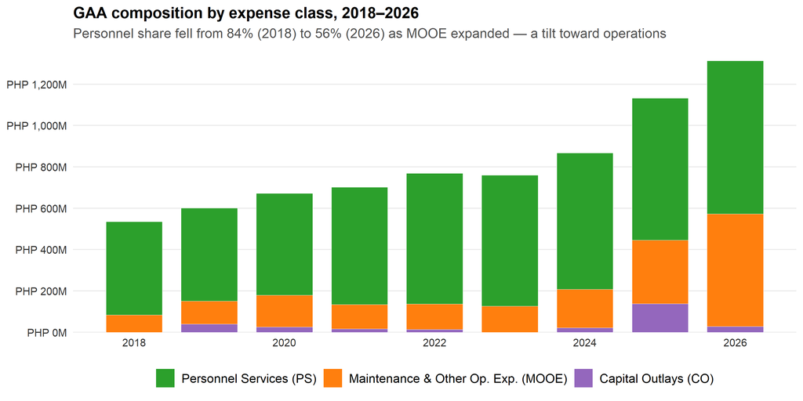

```r
ec_levels <- c("Personnel Services (PS)","Maintenance & Other Op. Exp. (MOOE)","Capital Outlays (CO)")
comp_ec <- df_long_all %>% filter(metric == "GAA", year <= 2026, expense_class %in% c("1PS","2MOOE","6CO")) %>%
  group_by(year, expense_class) %>% summarise(amount = sum(amount, na.rm = TRUE), .groups = "drop") %>%
  mutate(expense_class = factor(expense_class, levels = c("1PS","2MOOE","6CO"), labels = ec_levels))
ggplot(comp_ec, aes(year, amount, fill = expense_class)) +
  geom_col(width = 0.75, color = "white", linewidth = 0.2) +
  scale_fill_manual(values = ec_pal) +
  scale_y_continuous(labels = php_m_axis, breaks = pretty_breaks(6), limits = c(0, NA), expand = expansion(mult = c(0, .05))) +
  scale_x_continuous(breaks = seq(2018, 2026, 2)) +
  labs(title = "GAA composition by expense class, 2018–2026",
       subtitle = "Personnel share fell from 84% (2018) to 56% (2026) as MOOE expanded — a tilt toward operations", x = NULL, y = NULL) +
  theme_ncmf() + guides(fill = guide_legend(nrow = 1))
```

```r
comp_ec %>% group_by(year) %>% mutate(share = round(amount/sum(amount)*100)) %>% ungroup() %>%
  select(expense_class, year, share) %>% pivot_wider(names_from = year, values_from = share) %>%
  rename(`Expense class (% of GAA)` = expense_class) %>% kbl_clean(font = 12.5, na = "")
```

| Expense class (% of GAA) | 2018 | 2019 | 2020 | 2021 | 2022 | 2023 | 2024 | 2025 | 2026 |
| --- | --- | --- | --- | --- | --- | --- | --- | --- | --- |
| Personnel Services (PS) | 84 | 75 | 73 | 81 | 82 | 83 | 76 | 61 | 56 |
| Maintenance & Other Op. Exp. (MOOE) | 16 | 18 | 23 | 17 | 16 | 17 | 22 | 27 | 41 |
| Capital Outlays (CO) | 0 | 7 | 4 | 2 | 2 | 0 | 2 | 12 | 2 |

## 5.3 The largest P/A/Ps

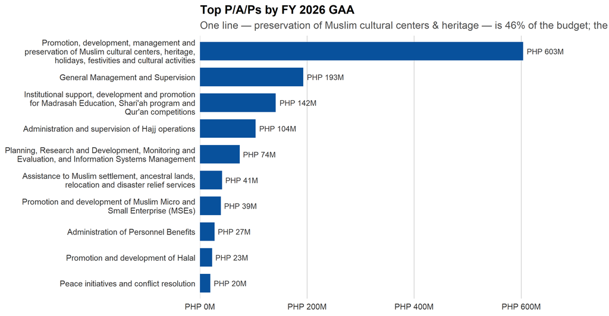

```r
top_paps <- pap_year %>% filter(year == 2026, !is.na(GAA), GAA > 0) %>% arrange(desc(GAA)) %>%
  slice_head(n = 10) %>% mutate(pap = factor(pap, levels = rev(pap)))
ggplot(top_paps, aes(pap, GAA)) +
  geom_col(fill = bar_fill, width = 0.72) +
  geom_text(aes(label = php_m(GAA)), hjust = -0.1, size = 3.2, color = "grey20") +
  coord_flip() + scale_x_discrete(labels = function(x) str_wrap(x, 50)) +
  scale_y_continuous(labels = php_m_axis, expand = expansion(mult = c(0, .25)), limits = c(0, NA)) +
  labs(title = "Top P/A/Ps by FY 2026 GAA",
       subtitle = "One line — preservation of Muslim cultural centers & heritage — is 46% of the budget; the top three are 71%",
       x = NULL, y = NULL) +
  theme_ncmf() + theme(panel.grid.major.y = element_blank(), panel.grid.major.x = element_line(color = "grey85"))
```

The budget is highly concentrated: a single P/A/P — **preservation of Muslim cultural centers, heritage, holidays and festivities (₱603M)** — is nearly half the total, more than three times the next line, General Management (₱193M). Institutional support for Madrasah/Shari’ah education (₱142M) and Hajj operations (₱104M) follow. The top three lines alone are 71% of the agency.

### Full P/A/P ranking, FY 2026 (interactive)

```r
pap_year %>% filter(year == 2026, !is.na(GAA)) %>%
  left_join(pap_year %>% filter(year == 2025) %>% transmute(pap, GAA25 = GAA), by = "pap") %>%
  transmute(`P/A/P` = pap, `NEP 2026 (M)` = NEP/1e6, `GAA 2026 (M)` = GAA/1e6,
            `GAA 2025 (M)` = GAA25/1e6, `Net chg 2026 (M)` = (GAA - NEP)/1e6) %>%
  arrange(desc(`GAA 2026 (M)`)) %>%
  dt_table(page = 10, money_cols = c("NEP 2026 (M)","GAA 2026 (M)","GAA 2025 (M)","Net chg 2026 (M)"))
```

| P/A/P | NEP 2026 (M) | GAA 2026 (M) | GAA 2025 (M) | Net chg 2026 (M) |
| --- | --- | --- | --- | --- |
| Promotion, development, management and preservation of Muslim cultural centers, heritage, holidays, festivities and cultural activities | 553.258 | 603.258 | 570.554 | 50 |
| General Management and Supervision | 192.86 | 192.86 | 198.224 | 0 |
| Institutional support, development and promotion for Madrasah Education, Shari'ah program and Qur'an competitions | 54.076 | 141.576 | 36.27 | 87.5 |
| Administration and supervision of Hajj operations | 93.948 | 103.948 | 74.044 | 10 |
| Planning, Research and Development, Monitoring and Evaluation, and Information Systems Management | 74.358 | 74.358 | 105.336 | 0 |
| Assistance to Muslim settlement, ancestral lands, relocation and disaster relief services | 41.394 | 41.394 | 21.507 | 0 |
| Promotion and development of Muslim Micro and Small Enterprise (MSEs) | 39.055 | 39.055 | 21.747 | 0 |
| Administration of Personnel Benefits | 27.248 | 27.248 | 50.987 | 0 |
| Promotion and development of Halal | 22.806 | 22.806 | 0.253 | 0 |
| Peace initiatives and conflict resolution | 19.56 | 19.56 | 13.664 | 0 |

[output cut: 5 more lines]

# 6 Half the agency: the cultural-heritage line

Because so much of NCMF rides on one P/A/P, it deserves a closer look. The **promotion and preservation of Muslim cultural centers, heritage, holidays and festivities** has been roughly half the agency every year and has grown in step with the total.

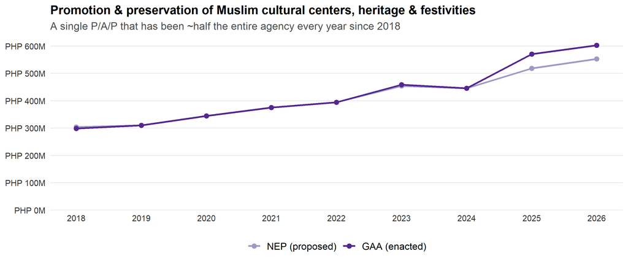

```r
heritage <- pap_year %>% filter(str_detect(pap, "cultural centers")) %>%
  select(year, NEP, GAA) %>% pivot_longer(-year, names_to = "metric", values_to = "amount") %>%
  filter(!is.na(amount)) %>%
  mutate(metric = factor(metric, levels = c("NEP","GAA"), labels = c("NEP (proposed)","GAA (enacted)")))
ggplot(heritage, aes(year, amount, color = metric, group = metric)) +
  geom_line(linewidth = 1.0) + geom_point(size = 2.2) +
  scale_color_manual(values = exec_pal) +
  scale_y_continuous(labels = php_m_axis, breaks = pretty_breaks(5), limits = c(0, NA), expand = expansion(mult = c(0, .05))) +
  scale_x_continuous(breaks = 2018:2026) +
  labs(title = "Promotion & preservation of Muslim cultural centers, heritage & festivities",
       subtitle = "A single P/A/P that has been ~half the entire agency every year since 2018", x = NULL, y = NULL) +
  theme_ncmf() + guides(color = guide_legend(nrow = 1))
```

The line grew from **₱299M (2018) to ₱603M (2026)** — a 102% rise — holding a 46–60% share throughout. Two things follow. First, because so much rides on one line, **its sub-components — which centers, which regions, which festivities, what upkeep — are not visible** in the budget documents, so communities cannot easily tell whether the money is reaching them. Second, together with Hajj operations and Madrasah/Shari’ah education, **cultural, religious and educational services are the core of NCMF’s budget** — the functions the agency exists to deliver — while the livelihood programs (Endowment, Muslim MSEs, Halal) remain barely 5% of the total.

# 7 Overall budget utilization

With no program-level execution data, utilization can only be read at the **agency aggregate**, and on a different basis from the appropriations above (all available funds, not just current-year new appropriations). On that basis NCMF is a strong absorber, with one clear exception.

## 7.1 Execution over time

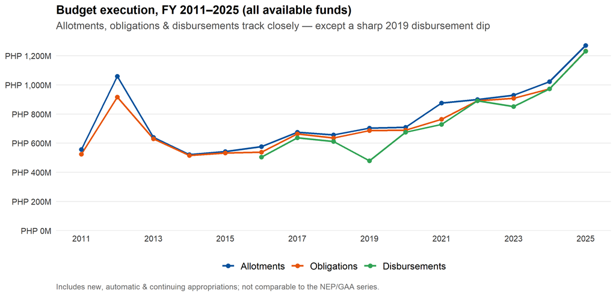

```r
el <- exec %>% select(year, Allotments, Obligations, Disbursements) %>%
  pivot_longer(-year, names_to = "stage", values_to = "amount") %>% filter(!is.na(amount)) %>%
  mutate(stage = factor(stage, levels = c("Allotments","Obligations","Disbursements")))
ggplot(el, aes(year, amount, color = stage, group = stage)) +
  geom_line(linewidth = 1.0) + geom_point(size = 2) +
  scale_color_manual(values = exec_pal) +
  scale_y_continuous(labels = php_m_axis, breaks = pretty_breaks(6), limits = c(0, NA), expand = expansion(mult = c(0, .05))) +
  scale_x_continuous(breaks = seq(2011, 2025, 2)) +
  labs(title = "Budget execution, FY 2011–2025 (all available funds)",
       subtitle = "Allotments, obligations & disbursements track closely — except a sharp 2019 disbursement dip",
       x = NULL, y = NULL, caption = "Includes new, automatic & continuing appropriations; not comparable to the NEP/GAA series.") +
  theme_ncmf() + guides(color = guide_legend(nrow = 1))
```

The three lines sit close together across fifteen years — what is released is, for the most part, obligated and paid — with one visible break in **2019**, when disbursements fell well below obligations.

## 7.2 Absorptive capacity

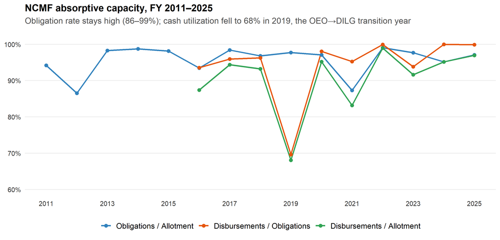

```r
absorp_long <- exec %>% select(year, oblig_allot, disb_oblig, disb_allot) %>%
  pivot_longer(-year, names_to = "ratio", values_to = "value") %>% filter(!is.na(value)) %>%
  mutate(ratio = factor(ratio, levels = c("oblig_allot","disb_oblig","disb_allot"),
    labels = c("Obligations / Allotment","Disbursements / Obligations","Disbursements / Allotment")))
ggplot(absorp_long, aes(year, value, color = ratio, group = ratio)) +
  geom_line(linewidth = 0.9) + geom_point(size = 2) +
  scale_color_manual(values = absorp_pal) +
  scale_y_continuous(labels = percent_format(accuracy = 1), limits = c(0.6, 1.02), breaks = seq(0.6, 1, 0.1)) +
  scale_x_continuous(breaks = seq(2011, 2025, 2)) +
  labs(title = "NCMF absorptive capacity, FY 2011–2025",
       subtitle = "Obligation rate stays high (86–99%); cash utilization fell to 68% in 2019, the OEO→DILG transition year",
       x = NULL, y = NULL) +
  theme_ncmf() + guides(color = guide_legend(nrow = 1))
```

NCMF **obligates almost everything released to it** (86–99%) and, in normal years, disburses nearly all of what it obligates. The exception is **2019**, when disbursement-to-obligation fell to ~70% (and disbursement-to-allotment to 68%) — the year the agency moved to the DILG, a textbook transition-year cash lag rather than a chronic problem, since the ratio recovered immediately afterward.

### Execution at a glance (interactive)

```r
exec %>% transmute(Year = year, `Allotments (M)` = Allotments/1e6, `Obligations (M)` = Obligations/1e6,
            `Disbursements (M)` = Disbursements/1e6, `O/A` = oblig_allot, `D/O` = disb_oblig, `D/A` = disb_allot) %>%
  dt_table(page = 15, money_cols = c("Allotments (M)","Obligations (M)","Disbursements (M)"),
           pct_cols = c("O/A","D/O","D/A"))
```

| Year | Allotments (M) | Obligations (M) | Disbursements (M) | O/A | D/O | D/A |
| --- | --- | --- | --- | --- | --- | --- |
| 2011 | 557.363 | 524.941 |  | 0.9418296514120958 |  |  |
| 2012 | 1059.579 | 916.747 |  | 0.8651992914166853 |  |  |
| 2013 | 640.59 | 629.581 |  | 0.9828142805850856 |  |  |
| 2014 | 521.948 | 515.417 |  | 0.9874872592672067 |  |  |
| 2015 | 543.075 | 532.933 |  | 0.9813248630483818 |  |  |
| 2016 | 576.721 | 538.874 | 503.999 | 0.9343755472750256 | 0.9352817170618735 | 0.8739043662360136 |
| 2017 | 675.398 | 664.672 | 637.544 | 0.9841189935415858 | 0.9591858841654229 | 0.9439530469441721 |
| 2018 | 656.73 | 635.884 | 612.168 | 0.9682578837574041 | 0.9627038893886306 | 0.9321456306244575 |
| 2019 | 703.05 | 687.162 | 478.558 | 0.9774013228077661 | 0.6964267523524292 | 0.680688428987981 |
| 2020 | 709.397 | 688.765 | 675.373 | 0.9709161442746446 | 0.980556503306643 | 0.9520381394339136 |

[output cut: 5 more lines]

PHP millions, all-funds basis. O/A = obligations ÷ allotment; D/O = disbursements ÷ obligations; D/A = disbursements ÷ allotment. Not comparable to the NEP/GAA appropriations series above.

# 8 Questions for discussion

1. **Is the envelope big enough?** NCMF’s FY 2026 budget works out to roughly **₱188 per Muslim Filipino per year** — about fifty centavos a day — and closer to **₱110** if the community is as large as NCMF itself estimates. Does that match the scale of the mandate?
2. **Are Hajj services meeting what pilgrims actually need?** Hajj operations receive ₱104M in 2026. Is that enough for accreditation and oversight of organizers, welfare and medical support, and protection against illegal recruitment — and what do pilgrims themselves experience?
3. **Is Madrasah education keeping up?** Institutional support for Madrasah education, Shari’ah and Qur’an programs is ₱142M. Does that meet the demand for quality Islamic and Arabic-language education among Muslim Filipino learners?
4. **Are the livelihood programs scaled to need?** Endowment, Muslim MSEs and Halal together are about **5% of the budget (~₱62M)**. Halal certification in particular is a growing economic opportunity. Should these grow — and should they grow *alongside* cultural and religious services rather than out of them?
5. **Does the spending reach every community?** Half the budget sits in one undifferentiated line. Can communities see which centers, regions and activities it funds — including those far from the traditional centers, and Muslim Filipinos living outside Mindanao?
6. **What is missing entirely?** Which needs of Muslim Filipino communities does this budget simply not address?
7. **What would program-level execution data show?** With no FAR No. 1, we can see that NCMF spends what it is given overall, but not *which* programs lag. Program-level records would show whether the cultural, education and livelihood lines are delivering at the same rate.

Underlying data: DBM NEP & GAA documents (current-year new appropriations, P/A/P level), FY 2018–2026; DBM-published execution aggregates (all available funds, agency level), FY 2011–2025. Per-person figures use the 2020 Census of Population and Housing (6,981,710 Filipinos, 6.4%, reporting Islam); NCMF has estimated the share at 10–11%, so per-person amounts should be read as an upper bound. No FAR No. 1 (P/A/P-level execution) was available for NCMF, so absorption is reported only at the agency aggregate, on a basis not directly comparable to the appropriations series. Prepared as the long-form companion to the NCMF budget briefing.